# Flowchart

# Flowchart Diagram

```r
library(DiagrammeR)
library(DiagrammeRsvg)

flowchart <- grViz("
  digraph flowchart {
    graph [overlap = true, fontsize = 24]
    node [shape = box, fontname = Helvetica,style = filled,color = LightBlue, fontsize = 24]
    A [label = 'Enrolled']
    B [label = 'Initiated']
    C1 [label = 'Treatment A']
    C2 [label = 'Treatment B']
    D11 [label = 'Retained in Study']
    D21 [label = 'Retained in Study']
    node [shape = oval, fontname = Helvetica,style = filled,color = Bisque]
    D12 [label = 'Lost of Follow Up']
    D22 [label = 'Lost of Follow Up']
    E112 [label = 'Not Tested']
    E212 [label = 'Not Tested']
    node [shape = circle, fontname = Helvetica,style = filled,color = LightSalmon]
    E111 [label = 'Treatment A \n Blood Tested']
    E211 [label = 'Treatment B \n Blood Tested']
    edge [color = grey,style=bold]
    A->B->C1->D11->E111
    D11->E112
    C1->D12
    B->C2->D21->E211
    D21->E212
    C2->D22
  }
")

flowchart
```

[interactive chart not shown]

```r
library(htmltools)
svg <- export_svg(flowchart)
## htmltools::html_print(HTML(svg))

## library(svglite)
## svglite::svglite("flowchat_ltfu.svg", width = 8, height = 10)
## flowchart
## dev.off()



## library(svglite)
## tmp <- tempfile()
## svglite::svglite(tmp, width = 10, height = 8)
## flowchart
## dev.off()
## library(rsvg)
## rsvg(tmp, "flowchart_ltfu.png", width = 8, height = 10)
## png(file = "flowchart_ltfu.png", width = 8, height = 12)
## flowchart
## dev.off()
## library(svglite)
## svg <- export_svg(flowchart)
## render_graph(flowchart, output = "svg")
## export_graph(
##     graph = svg
##   , file_name = "flowchart_ltfu.png"
##   , file_type = "PNG"
## )
```

# Flowchart Diagram LR

```r
mermaid('graph LR
A("<b>Enrollment</b>") === B1("<b>No Compliance</b>")
A === B2("<b>Treatment</b>")
A === B3("<b>Placebo</b>")

B1 --> C12("<b>Survival</b>")
B1  --> C11(("<b>Death</b>"))
B2  --> C22("<b>Survival</b>")
B2 --> C21(("<b>Death</b>"))
B3 == "probability" ==> C32("<b>Survival</b>")
B3 --> C31(("<b>Death</b>"))

C32 == "probability" ==> D1["<b>Initiated New Treatment</b>"]
C32 ==> D2["<b>No New Treatment</b>"]

D1 --> E2("<b>Survival</b>")
D1 --> E1(("<b>Death</b>"))

D2 --> E22("<b>Survival</b>")
D2 --> E21(("<b>Death</b>"))

style A fill:#99ffff,stroke:#333,stroke-width:0px
style B1 fill:#99ffff,stroke:#333,stroke-width:0px
style B2 fill:#99ffff,stroke:#333,stroke-width:0px
style B3 fill:#99ffff,stroke:#333,stroke-width:0px

style D1 fill:#99ffff,stroke:#333,stroke-width:0px
style D2 fill:#99ffff,stroke:#333,stroke-width:0px

style C11 fill:#ff9999,stroke:#333,stroke-width:0px
style C21 fill:#ff9999,stroke:#333,stroke-width:0px
style C31 fill:#ff9999,stroke:#333,stroke-width:0px
style E1 fill:#ff9999,stroke:#333,stroke-width:0px
style E21 fill:#ff9999,stroke:#333,stroke-width:0px

style C12 fill:#99ffff,stroke:#333,stroke-width:0px
style C22 fill:#99ffff,stroke:#333,stroke-width:0px
style C32 fill:#99ffff,stroke:#333,stroke-width:0px
style E2 fill:#99ffff,stroke:#333,stroke-width:0px
style E22 fill:#99ffff,stroke:#333,stroke-width:0px;
style C32 weigth:bold;
')
```

[interactive chart not shown]

# Confounding Diagram

```r
grViz("
digraph Confounding{
      graph [overlap = true, fontsize = 10,rankdir=LR]
      subgraph cluster_0 {
        overlap = true; fontsize = 10;
        node [shape = box, fontname = Helvetica,style = filled,color = LightBlue]
        A [label = 'Confounder',group=1]
        B [label = 'Intervention',group=1]
        C [label = 'Outcome',group=1]
      edge [color = grey,style=bold]
      A->B->C
      }
      edge [color = grey,style=bold]
      A->C
      }
      ")
```

[interactive chart not shown]

# Customized flowchart with ggplot2

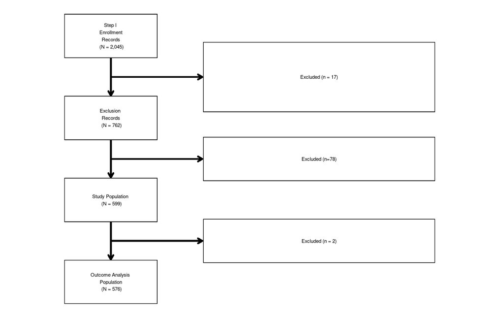

```r
library(ggplot2)

data <- data.frame(x= 1:100, y= 1:100)

data %>%
  ggplot(aes(x, y)) +
  scale_x_continuous(minor_breaks = seq(10, 100, 10)) +
  scale_y_continuous(minor_breaks = seq(10, 100, 10)) +
  theme_linedraw() -> p



xm1 <- 20
xm2 <- 65
w1 <- 10
w2 <- 25
y1 <- 100
ht <- 15
height_box <- 15
num_vertical_arrow <- 3
num_vertical_box <- num_vertical_arrow + 1
height_arrow <- (100 - height_box * num_vertical_box) / num_vertical_arrow
ytop <- seq(100, 0, -((100 - height_box * num_vertical_box)/num_vertical_arrow + height_box))

bw <- 0.25
width_border <- 0.25
size_font <- 2
width_arrow <- 0.8



label1 <- "Step I \n Enrollment \n Records \n (N = 2,045)"
label2 <- "Exclusion \n Records \n (N = 762)"
label3 <- "Study Population \n (N = 599)"
label4 <- "Outcome Analysis \n Population \n (N = 576)"



p <- p + geom_rect(
             xmin = xm1 - w1
           , xmax = xm1 + w1
           , ymin = y1 - ht
           , ymax = ytop[1]
           , color = 'black'
           , fill = 'white'
           , size = bw
         )
p <- p + annotate(
             'text'
           , x = xm1
           , y = ytop[1] - ht / 2
           , label = label1
           ## , parse = TRUE
           , size = size_font
         )


p <- p + geom_rect(
             xmin = xm1 - w1
           , xmax = xm1 + w1
           , ymin = ytop[2] - ht
           , ymax = ytop[2]
           , color = 'black'
           , fill = 'white'
           , size = bw
         )
p <- p + annotate(
             'text'
           , x = xm1
           , y = ytop[2] -  ht / 2
           , label = label2
           , size = size_font
         )

p <- p + geom_segment(
        x = xm1
      , xend = xm1
      , y = ytop[1] - ht - bw
      , yend = ytop[2] + bw
      , size = width_arrow
      , linejoin = "round"
      , lineend = "round"
      , arrow = arrow(length = unit(2, "mm"), type= "open"))


## row 3
p <- p + geom_rect(
             xmin = xm1 - w1
           , xmax = xm1 + w1
           , ymin = ytop[3] - ht
           , ymax = ytop[3]
           , color = 'black'
           , fill = 'white'
           , size = bw
         )
p <- p + annotate(
             'text'
           , x = xm1
           , y = ytop[3] -  ht / 2
           , label = label3
           , size = size_font
         )

p <- p + geom_segment(
        x = xm1
      , xend = xm1
      , y = ytop[2] - ht - bw
      , yend = ytop[3] + bw
      , size = width_arrow
      , linejoin = "round"
      , lineend = "round"
      , arrow = arrow(length = unit(2, "mm"), type= "open"))

## row 4
p <- p + geom_rect(
             xmin = xm1 - w1
           , xmax = xm1 + w1
           , ymin = ytop[4] - ht
           , ymax = ytop[4]
           , color = 'black'
           , fill = 'white'
           , size = bw
         )
p <- p + annotate(
             'text'
           , x = xm1
           , y = ytop[4] -  ht / 2
           , label = label4
           , size = size_font
         )

p <- p + geom_segment(
        x = xm1
      , xend = xm1
      , y = ytop[3] - ht - width_border
      , yend = ytop[4] + width_border
      , size = width_arrow
      , linejoin = "round"
      , lineend = "round"
      , arrow = arrow(length = unit(2, "mm"), type= "open"))



## column b1
labelb1 <- "Excluded (n = 17)"
labelb2 <- "Excluded (n=78)"
labelb3 <- "Excluded (n = 2)"

p <- p + geom_rect(
             xmin = xm2 - w2
           , xmax = xm2 + w2
           , ymin = ytop[1] - height_box - height_arrow / 2 - ht / 2 * 1.6
           , ymax = ytop[1] - height_box - height_arrow / 2 + ht / 2 * 1.6
           , color = 'black'
           , fill = 'white'
           , size = bw
         )
p <- p + annotate(
             'text'
           , x = xm2
           , y = ytop[1] - height_box - height_arrow / 2
           , label = labelb1
           , size = size_font
         )

p <- p + geom_segment(
        x = xm1 + width_border
      , xend = xm2 - w2 - width_border
      , y = ytop[1] - height_box - height_arrow / 2
      , yend = ytop[1] - height_box - height_arrow / 2
      , size = width_arrow
      , linejoin = "round"
      , lineend = "round"
      , arrow = arrow(length = unit(2, "mm"), type= "open"))

## column b2
p <- p + geom_rect(
             xmin = xm2 - w2
           , xmax = xm2 + w2
           , ymin = ytop[2] - height_box - height_arrow / 2 - ht / 2
           , ymax = ytop[2] - height_box - height_arrow / 2 + ht / 2
           , color = 'black'
           , fill = 'white'
           , size = bw
         )
p <- p + annotate(
             'text'
           , x = xm2
           , y = ytop[2] - height_box - height_arrow / 2
           , label = labelb2
           , size = size_font
         )

p <- p + geom_segment(
        x = xm1 + width_border
      , xend = xm2 - w2 - width_border
      , y = ytop[2] - height_box - height_arrow / 2
      , yend = ytop[2] - height_box - height_arrow / 2
      , size = width_arrow
      , linejoin = "round"
      , lineend = "round"
      , arrow = arrow(length = unit(2, "mm"), type= "open"))


## column b3

p <- p + geom_rect(
             xmin = xm2 - w2
           , xmax = xm2 + w2
           , ymin = ytop[3] - height_box - height_arrow / 2 - ht / 2
           , ymax = ytop[3] - height_box - height_arrow / 2 + ht / 2
           , color = 'black'
           , fill = 'white'
           , size = bw
         )
p <- p + annotate(
             'text'
           , x = xm2
           , y = ytop[3] - height_box - height_arrow / 2
           , label = labelb3
           , size = size_font
         )

p <- p + geom_segment(
        x = xm1 + width_border
      , xend = xm2 - w2 - width_border
      , y = ytop[3] - height_box - height_arrow / 2
      , yend = ytop[3] - height_box - height_arrow / 2
      , size = width_arrow
      , linejoin = "round"
      , lineend = "round"
      , arrow = arrow(length = unit(2, "mm"), type= "open"))

p <- p + theme_void()


p
```

# CONSORT Flow Diagram

- consort plot using tgsify package

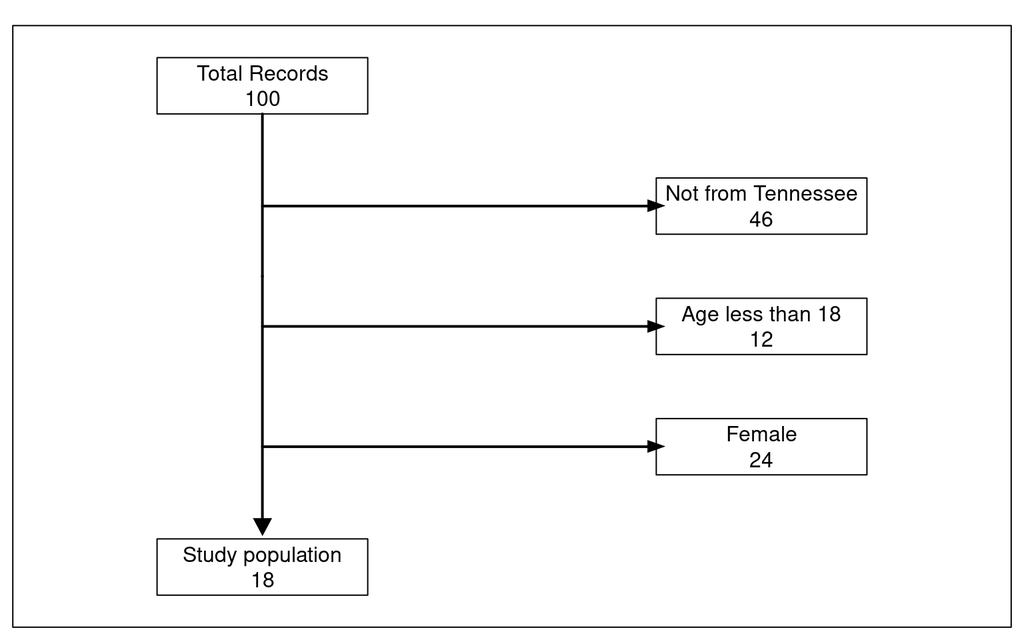

```r
library(Wu)
library(tgsify)

df <- data.frame(
    age = 1:100
  , sex = sample(c("M", "F"), size = 100, replace = TRUE)
  , state = sample(c("Tennessee", "Kentucky"), size = 100, replace = TRUE)
)


df %>%
    mutate(consort = case_when(
               state !=  "Tennessee" ~ "2 2 Not from Tennessee"
             , age < 18 ~ "3 2 Age less than 18"
             , sex != "M" ~ "4 2 Female"
             , TRUE ~ "5 1 Study population"
           )) %>%
    le("consort") %>%
    two_column_consort("Total Records")
```

R version 4.2.0 (2022-04-22) Platform: x86_64-pc-linux-gnu (64-bit) Running under: Ubuntu 20.04.3 LTS

Matrix products: default BLAS: /usr/lib/x86_64-linux-gnu/blas/libblas.so.3.9.0 LAPACK: /usr/lib/x86_64-linux-gnu/lapack/liblapack.so.3.9.0

locale: [1] LC_CTYPE=C.UTF-8 LC_NUMERIC=C LC_TIME=C.UTF-8  
[4] LC_COLLATE=C.UTF-8 LC_MONETARY=C.UTF-8 LC_MESSAGES=C.UTF-8  
[7] LC_PAPER=C.UTF-8 LC_NAME=C LC_ADDRESS=C  
[10] LC_TELEPHONE=C LC_MEASUREMENT=C.UTF-8 LC_IDENTIFICATION=C

attached base packages: [1] stats graphics grDevices utils datasets methods base